# COVID Stock Market Returns

Time Series Analysis with Python

Devansh Sachar

2026-06-01

## 1. The Business Question

A time series is data measured in order over time.

For this presentation, the question is simple:

**How did COVID-19 change stock market behavior, and what can analytics teams learn from it?**

We focus on four ideas that are easy to explain:

**Trend**  
Long-run direction

**Returns**  
Daily gains or losses

**Volatility**  
Risk and uncertainty

**Anomalies**  
Unusual market days

Dataset source used in this file: `Python fallback: S&P 500 style COVID return series`. To use live S&P 500 data, set `USE_LIVE_DATA = True` in the first Python chunk.

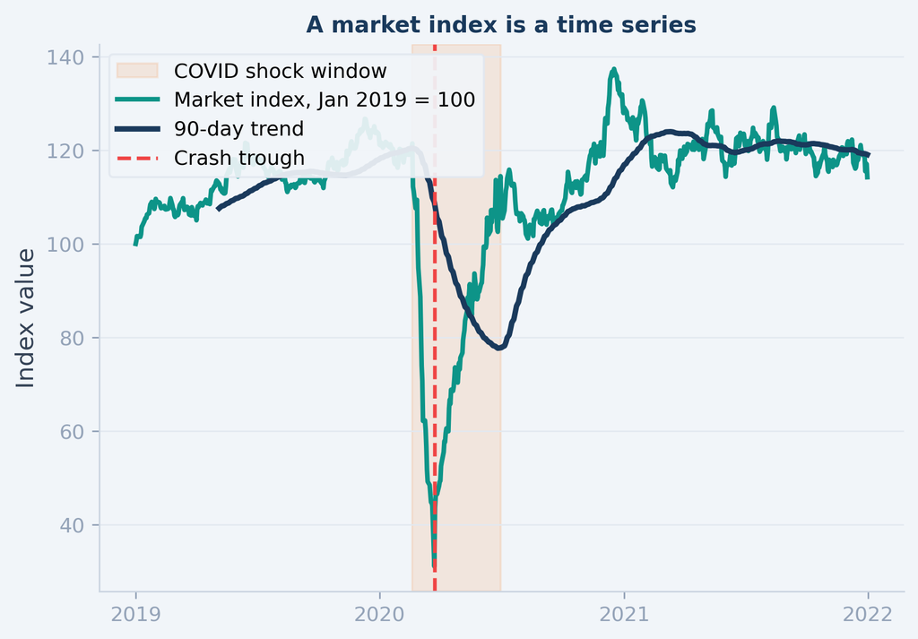

## 2. Prices Show the Story, Returns Show the Reaction

Prices are useful for the big picture, but returns are better for analysis.

**Price**  
Shows the level of the market. It usually trends over time.

**Return**  
Shows the percentage change from one trading day to the next.

Return = (Today’s price - Yesterday’s price) / Yesterday’s price

Why it matters: managers, investors, and analysts usually care about returns because returns measure gain, loss, and risk.

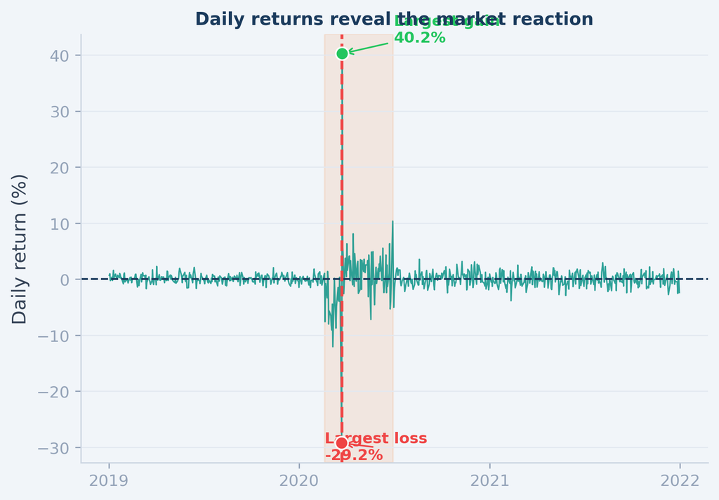

## 3. COVID Created a Clear Market Shock

A market shock is a sudden event that changes expectations.

During the COVID period, investors reacted to:

- Lockdowns and uncertainty
- Business closures
- Policy responses
- Vaccine and reopening expectations

-74.4%

drop in the crash window

10.5%

peak 30-day daily volatility

10

extreme return days flagged

The point is not just that the market fell. The bigger lesson is that the behavior of the time series changed.

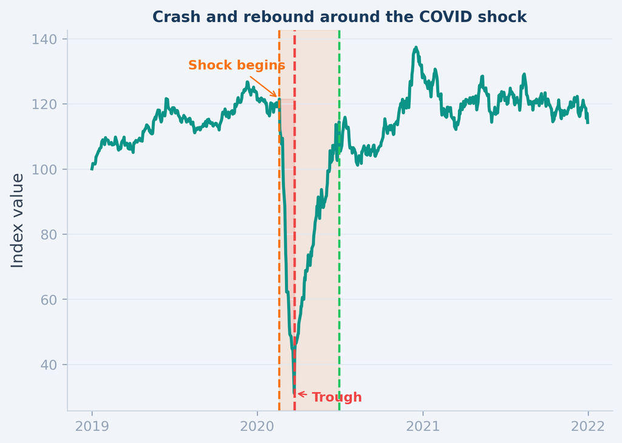

## 4. Volatility Clustering: Big Moves Come Together

One important time series pattern is volatility clustering.

That means large movements tend to be followed by more large movements.

**Before COVID:** returns were smaller and calmer.  
**During COVID:** positive and negative swings happened back to back.

This is why risk teams track rolling volatility instead of looking only at average return.

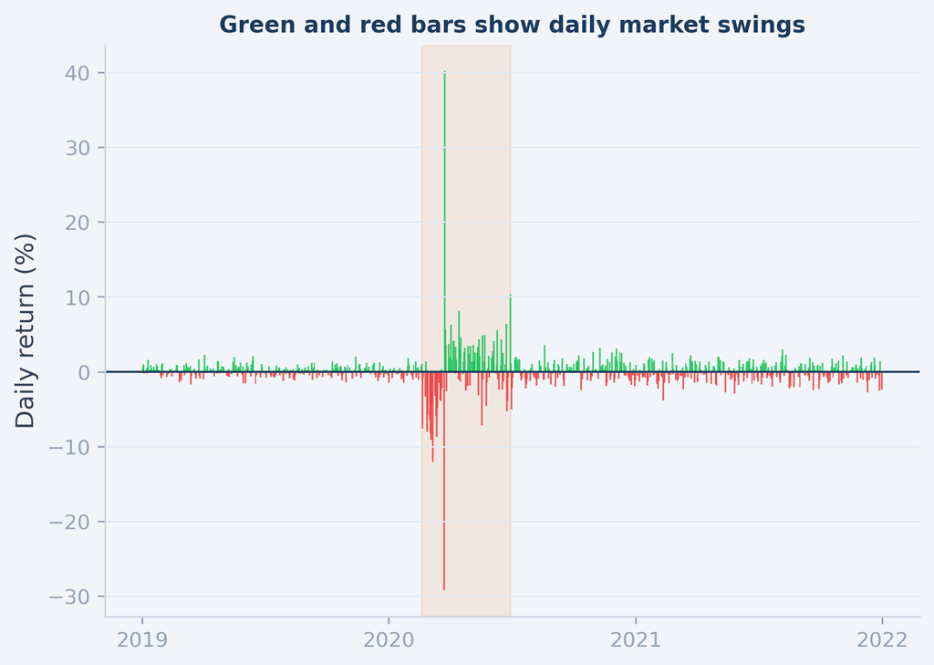

## 5. Rolling Volatility Measures Risk

Rolling volatility calculates the standard deviation of returns over a moving window.

Here we use a 30-trading-day window.

0.71%

pre-COVID daily volatility

6.52%

COVID shock volatility

1.22%

post-shock volatility

Simple interpretation: the market became less predictable, so the risk of making a wrong forecast increased.

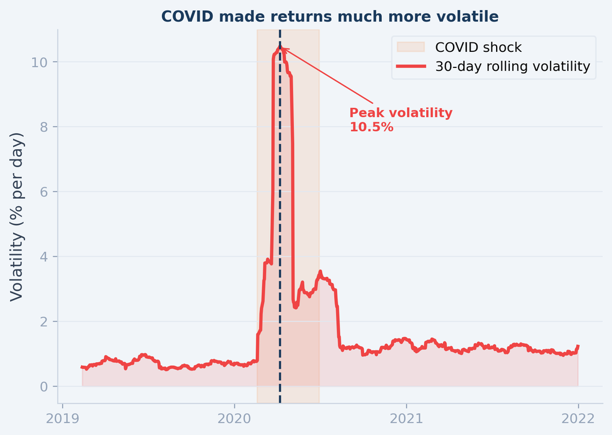

## 6. Anomaly Detection Finds Extreme Days

A simple way to identify unusual days is the 3-sigma rule.

Flag a day if |return - average return| > 3 × standard deviation

This works well for teaching because it is easy to explain:

- Calculate normal behavior
- Draw upper and lower limits
- Flag points outside those limits

The red dots are days where the market moved far more than normal.

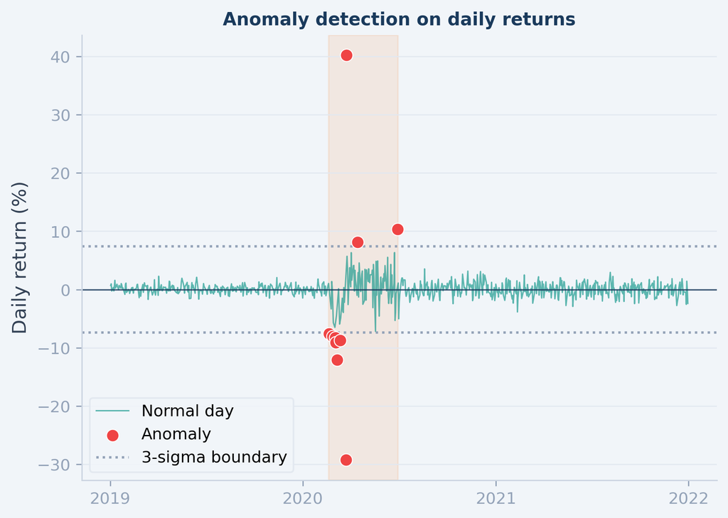

## 7. Biggest Return Days Tell the Crisis Story

Extreme days are useful because they turn a long time series into a short list of business events.

Instead of asking people to read hundreds of rows, we highlight the days that need explanation.

In real stock data, these dates would be matched with news: lockdown announcements, central bank actions, fiscal stimulus, earnings warnings, and vaccine updates.

|  | Date | Daily Return | 30-Day Volatility |
| --- | --- | --- | --- |
| 320 | Mar 24, 2020 | +40.22% | 10.08% |
| 319 | Mar 23, 2020 | -29.25% | 5.99% |
| 308 | Mar 06, 2020 | -12.06% | 3.80% |
| 389 | Jun 29, 2020 | +10.35% | 3.43% |
| 306 | Mar 04, 2020 | -9.08% | 3.25% |
| 312 | Mar 12, 2020 | -8.74% | 3.91% |

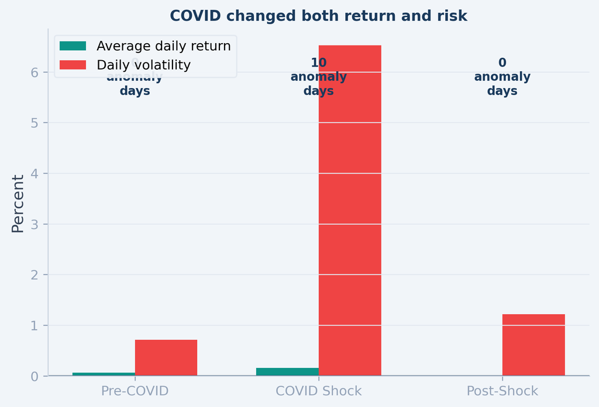

## 8. Forecasting Lesson and Final Takeaways

Forecasting after a shock is difficult because the future may not look like the past.

A simple forecast uses recent average return and recent volatility.

**Key lesson:** after COVID, uncertainty is as important as direction.

01Use returns, not just prices

Returns reveal gains, losses, risk, and market reaction.

02Track rolling volatility

Volatility shows when the market becomes unpredictable.

03Flag anomalies early

Extreme days can trigger deeper business analysis and risk controls.

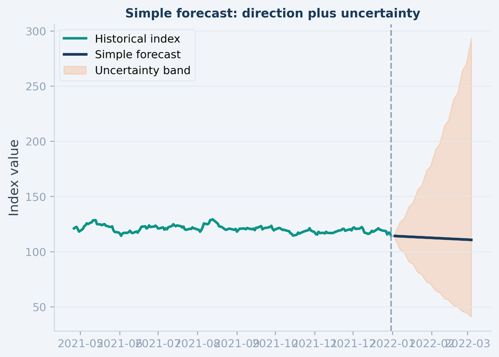

Final message: time series analysis helps marketing and analytics teams convert messy daily market data into a simple story about trend, risk, shock, and recovery.